# Stochastic Process

Author

Ritesh B

## Intro

A stochastic process is a set of random variables that depicts how a system changes over time. It explains how a system’s state varies at various times or locations, frequently in unforeseen or random ways.

A **stochastic process** is defined as a collection of random variables indexed by time or space: {$X(t)$, $t \in T$}, where $X(t)$ is a random variable representing the state of the system at a time (or location), and $T$ is the index set (e.g., time, space, or another parameter).

The **index set** of a stochastic process refers to the collection of indices or time points at which the process is observed. It provides the framework within which the random variables of the process are defined and analysed. The index set essentially determines the “when” or “where” of the observations of the process. Here are two main types of index sets: Discrete Index Set and Continuous Index Set.

An instance of an index set in a **discrete-time** stochastic process could be the collection of non-negative integers (e.g., $T =$ {$0, 1, 2, 3, ...$}), where each integer denotes a different time step or observation point. The state of the system is monitored at discrete time steps in a Markov chain, which is an example of a process with a discrete index set. In a **continuous-time** stochastic process, the index set might be the set of all real numbers (e.g., $T = [0, \infty)$), where each real number corresponds to a point in continuous time. An example of a process with a continuous index set is Brownian motion, where the process is observed at every instant in time.

Some important properties are:

- **Stationarity:** A stochastic process is stationary if its statistical properties, like mean and variance, do not change over time. If these properties vary, the process is non-stationary.
- **Markov Property:** A process has the Markov property if the future state depends only on the current state and not on the sequence of past states.
- **Independent Increments:** In some processes, the changes (increments) over non-overlapping time intervals are independent of each other. Example: Poisson process.
- **Memory:** The process may either have memory (where future states depend on past states) or be memoryless (as in the case of Markov processes).

## **Discrete Random Walk**

A discrete random walk is a stochastic process where steps occur at discrete time intervals, and the state at each step depends on the random choice of step size. Here’s an example where the steps are chosen from a binomial distribution (e.g., a coin toss determining whether the step is +1 or -1)

The discrete random walk can be simulated in R as follows. First, we demonstrate how a random walk.

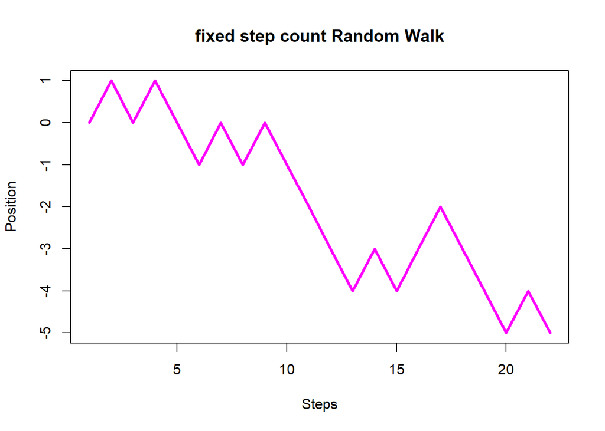

```r
posi = 0
st = 0
positions = c(posi)
while (st <= 20) {
  posi = posi + sample(c(-1, 1), 1)
  positions = c(positions, posi)
  st = st + 1
}
plot(positions, type = "l",
     col = "magenta", lwd = 3,
     xlab = "Steps", ylab = "Position",
     main = "fixed step count Random Walk")
```

For multiple walk

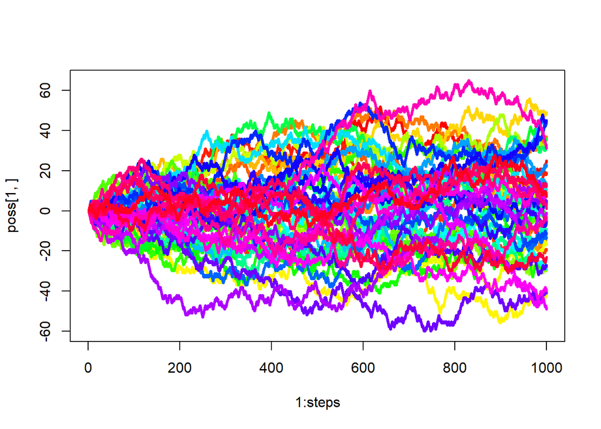

```r
steps = 1000
walk_count = 50

poss = matrix(0, nrow = walk_count, ncol = steps)
for (i in 1:walk_count) {
  for (j in 2:steps) {
    poss[i, j] = poss[i, j-1] + sample(c(-1, 1), 1)
  }
}
plot(1:steps, poss[1,], lwd = 3,
     col = rainbow(50)[1], type = "l",
     ylim = c(min(poss), max(poss)))
for (k in 2:walk_count) {
  lines(1:steps, poss[k,], lwd = 3, col = rainbow(50)[k], type = "l")
}
```

## Continuous random walk

The **Continuous-Time Random Walk (CTRW)** is a versatile stochastic process used to model systems where events occur randomly in both space and time. Unlike classical random walks, where the steps occur at regular intervals, in CTRWs, the waiting time between successive steps is a random variable.

In a CTRW, the dynamics are characterized by two random variables: the **step size** and the **waiting time**. The step size determines the spatial displacement, while the waiting time specifies the duration between successive steps.

Here we consider displacements, or step sizes, are sampled independently from a uniform distribution, typically defined over a symmetric interval, such as $[-a, a]$, where $a > 0$. The uniform distribution ensures that all step sizes within the interval have an equal probability of occurrence, creating a process with no preferred direction or magnitude of movement.

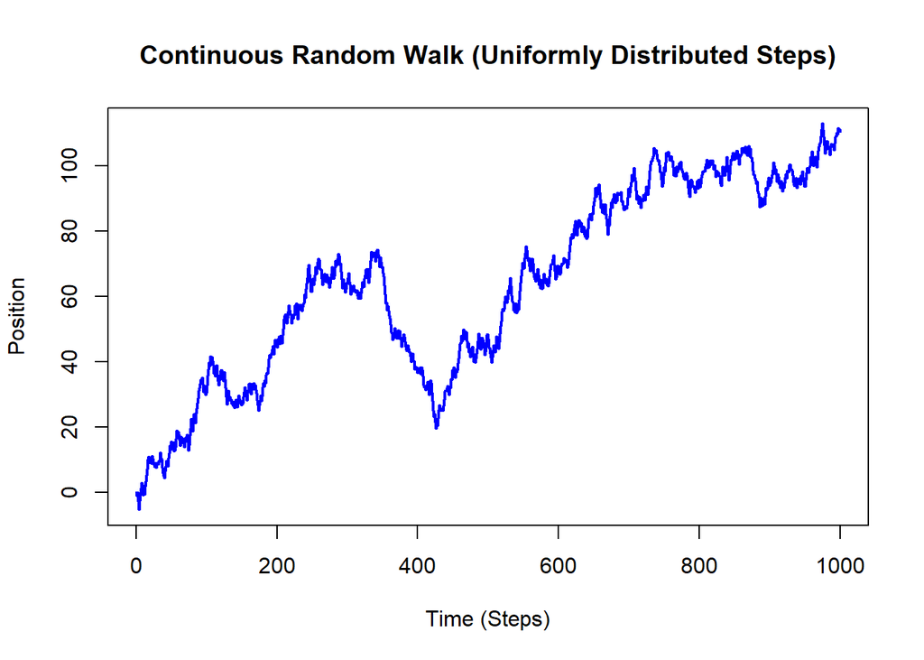

```r
n_steps = 1000
st_min = -3
st_max = 3
initial = 0

steps = runif(n_steps, min = st_min, max = st_max)

positions = cumsum(c(initial, steps))

time = 0:n_steps

plot(time, positions, type = "l", col = "blue", lwd = 2,
  xlab = "Time (Steps)", ylab = "Position",
  main = "Continuous Random Walk (Uniformly Distributed Steps)")
```

The plot shows a continuous random walk with random step sizes sampled uniformly.

One of the key features of CTRWs is their flexibility in modeling different types of behavior by choosing appropriate distributions for the step size and waiting time. For instance, when the waiting times follow an exponential distribution, the process reduces to a **Poisson process**, leading to standard diffusion. However, if the waiting times exhibit a heavy-tailed distribution (e.g., a power law), the process captures **anomalous diffusion**, which is observed in many natural and complex systems.

Here’s an example where waiting times follow an exponential distribution while step sizes follow a uniform distribution:

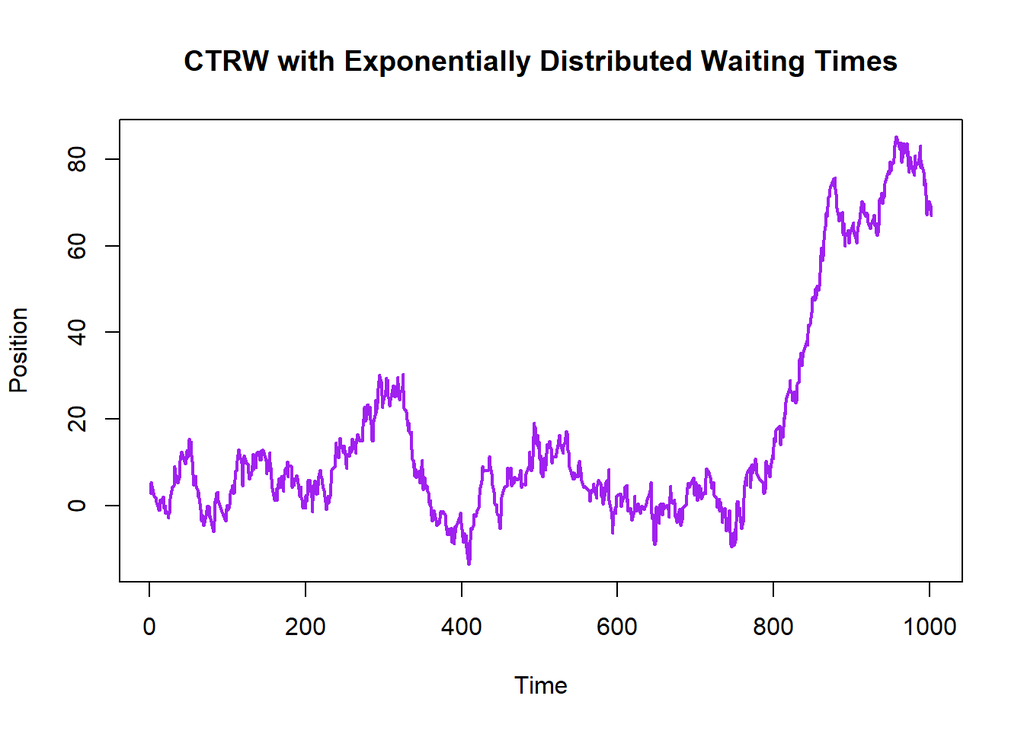

```r
n_step = 1000
s_min = -3
s_max = 3
rate = 1

set.seed(321)
steps = runif(n_step, min = s_min, max = s_max)
wait_time <- rexp(n_step, rate = rate)
time <- cumsum(wait_time)
positions <- cumsum(steps)

plot(time, positions, type = "l", col = "purple", lwd = 2,
  xlab = "Time", ylab = "Position",
  main = "CTRW with Exponentially Distributed Waiting Times")
```

## Wiener Process

The Wiener process, also known as Brownian motion, is a fundamental concept in probability theory and stochastic processes.

**Definition:** A Wiener process $W(t)$ is a stochastic process that satisfies the following properties:

1. **Initial value**: $W(0) = 0$.
2. **Independent increments**: The increments $(W(t_2) - W(t_1))$ are independent of $(W(t_1) - W(t_0))$ for any $t_0 < t_1 < t_2$. The process is also Markovian, meaning the future state depends only on the current state and not on the past trajectory.
3. **Stationary increments**: The increments $(W(t + h) - W(t))$ have the same distribution as $W(h)$.
4. **Gaussian increments**: For any $t > s$, the increment $W(t) - W(s) \sim N(0, t - s)$ is normally distributed with mean $0$ and variance $(t - s)$. The variance of $W(t)$ grows linearly with time, i.e., $Var(W(t)) = t$, but expectation fixed as $E(W(t)) = 0$. In differential form,

   $$dW = \sqrt(dt). Z$$

   where $Z \sim N(0, 1)$ is a standard normal random variable.
5. **Continuity**: The function $W(t)$ is almost surely continuous.

A more general process is obtained if we define $X(t)=\mu+\sigma W(t)$. In this case, $X(t)$ is a Brownian motion with $E(X(t)) = \mu$, and $Var(X(t)) = \sigma^2 t$.

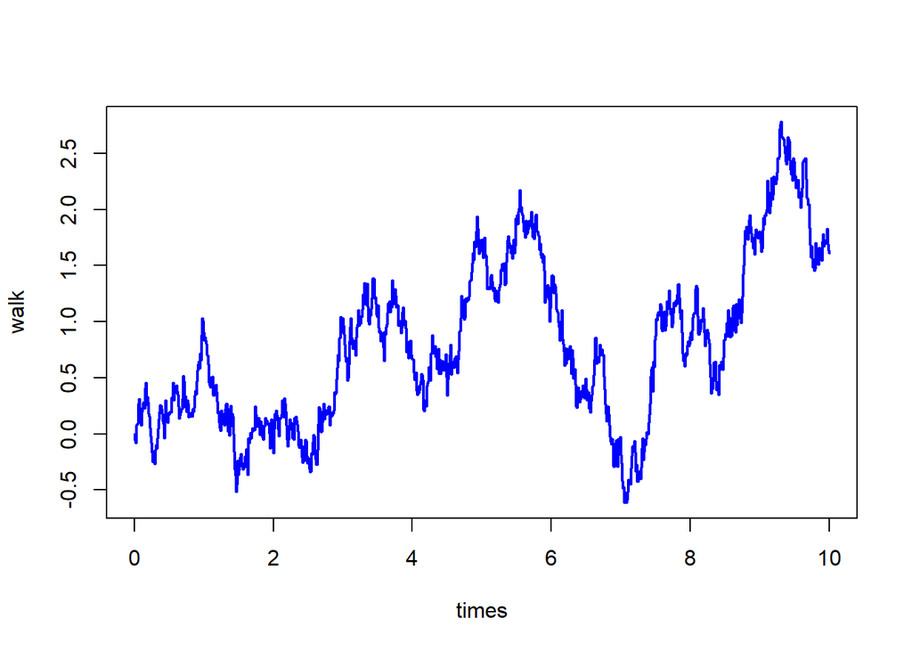

```r
steps = 1000
mu = 0
dt = 0.01

set.seed(123)
increment = c(0, rnorm(steps, mu, sqrt(dt)))
walk = cumsum(increment)

times = seq(0, steps*dt, by = dt)

plot(times, walk, type = "l", lwd = 2, col = "blue")
```

For more multiple walk..

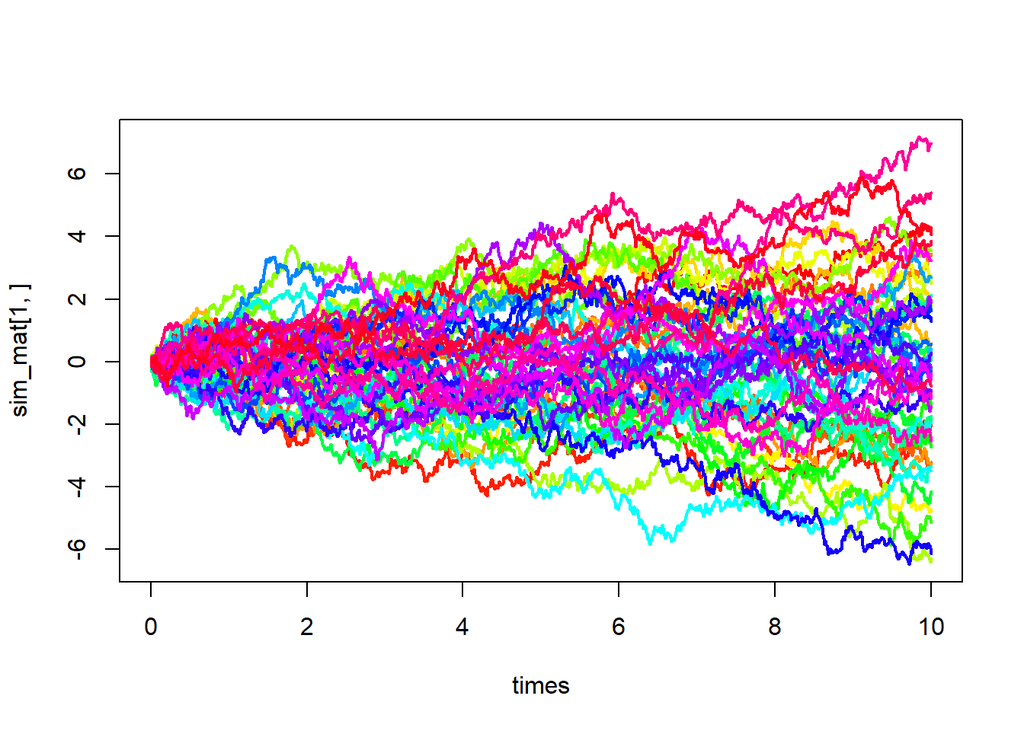

```r
steps = 1000
mu = 0
dt = 0.01
walk = 50
sim_mat = matrix(NA, nrow = walk, ncol = steps + 1)

#set.seed(123)
for (i in 1:walk) {
    increment = c(0, rnorm(steps, mu, sqrt(dt)))
    sim_mat[i, ] =  cumsum(increment)
}

times = seq(0, steps*dt, by = dt)

plot(times, sim_mat[1,], type = "l", lwd = 2,
     col = rainbow(walk)[1],
   ylim = c(min(sim_mat), max(sim_mat)))
for (k in 2:walk) {
  lines(times, sim_mat[k,],
    lwd = 2, col = rainbow(walk)[k],
    type = "l")
}
```

Checking the variance

```r
t = 500*dt
v_t = var(sim_mat[,500])
cat("At the time", t, "variance is", v_t)
```

```
At the time 5 variance is 4.281417
```

**Branching process**

A **branching process** is a stochastic process that models the growth of populations where individuals reproduce independently. The process starts with an initial population (usually one individual), and in each generation, every individual produces offspring according to a predefined probability distribution. The process can either grow indefinitely or die out depending on the reproduction probabilities.

Mathematically, if $Z_n$ represents the population size at generation $n$, and each individual in generation $n$ produces offspring independently from a reproduction distribution, then:

$$Z_{n+1} = \sum_{i=1}^{Z_n} X_i$$
where $X_i$ are independent and identically distributed random variables representing the number of offspring.

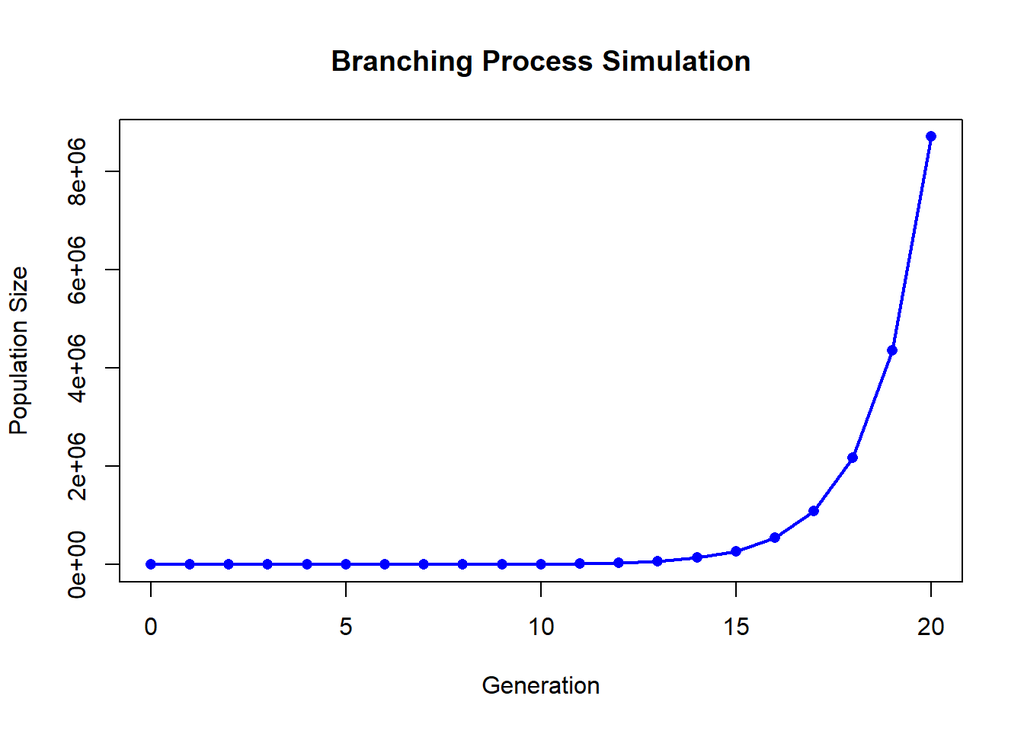

```r
set.seed(42)
gen = 20
offs_mean = 2
offs_dist = function() rpois(1, offs_mean)

pop = numeric(gen + 1)
pop[1] = 5  # Start with 1 individual

# Simulate the branching process
for (g in 1:gen) {
  pop[g + 1] <- sum(replicate(pop[g], offs_dist()))
}

# Plot the branching process
plot(0:gen, pop, type = "o", col = "blue",
     lwd = 2, pch = 16,
  xlab = "Generation", ylab = "Population Size",
  main = "Branching Process Simulation")
```